# Climate Change

Ernesto

April 7, 2017

## Climate Change

This is something that might be too late for our next presentation, but it’s cool enough and here it is.  
On top of the usual fish movement, let’s just assume that “capacity” also moves, going north and off-shore. This is how it looks like with no fishing:

[video not shown]

Let’s call this climate change.

[video not shown]

Notice that strictly speaking the overall biomass and capacity is constant, it just progressively moves north-west. Take our usual simple scenario with 1 fleet, 100 boats and no regulations. Let’s run this simulation twice keeping everything constant except turning on/off climate change.

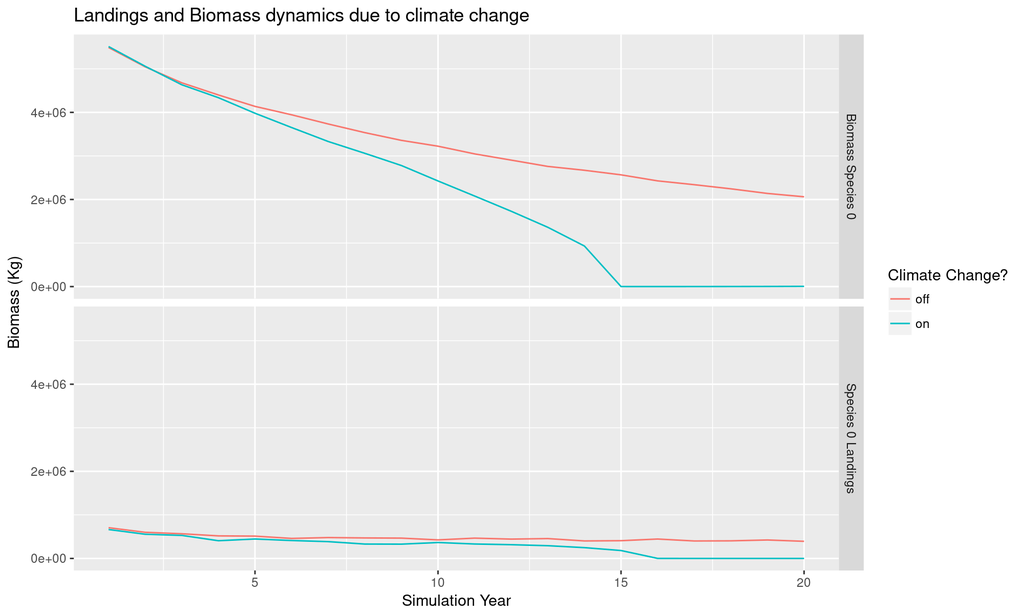

Even though the fishing power is exactly the same, with climate change we get complete biomass collapse. More importantly, this collapse is not associated with more landings (landings under climate change are in fact lower every year).  
What is going on? Two things:

1. As fish is boxed into a smaller and smaller area (north-west corner), it becomes easier for boats to catch them
2. As fish gets concentrated, most areas are either empty or extremely full. Since logistic growth means more fish spawns in cells half-full you get lower recruitment for the same amount of biomass

The first point is quite important but hidden away if looking at landings alone. If we observe CPUE we see the following:

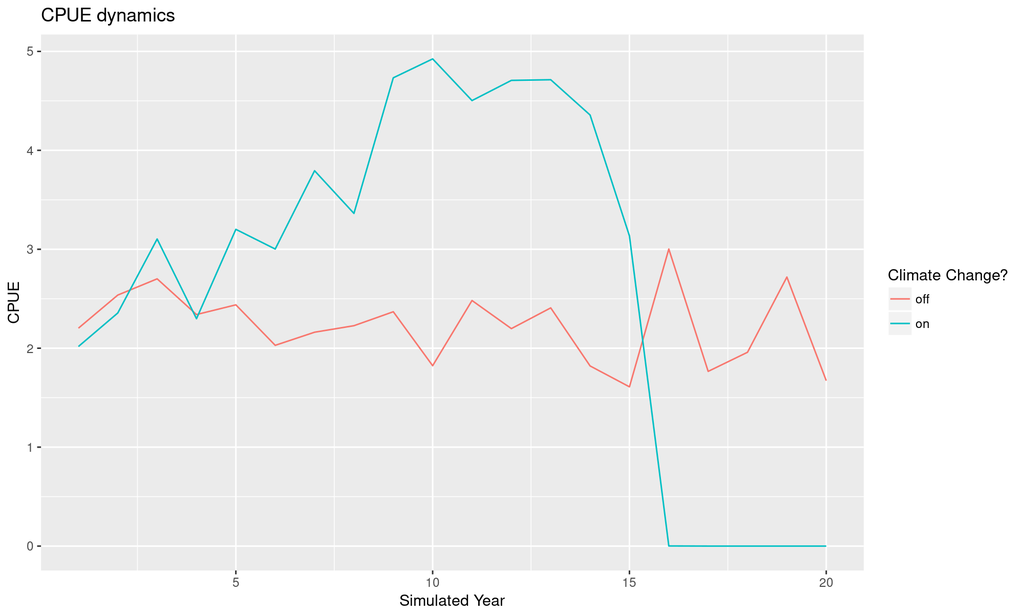

As you can see, the catches per hour fished double between year 1 and year 10 when climate change occurs (while they are fairly constant with no climate change). This is because by year 10 there are quite a lot of areas with very high capacity and biomass. Since our fishers imitate one another, this results in agents concentrating in those high reward areas. This way they manage to kill off a lot of fish very quickly (high CPUE).  
This is not visible in the landings data however because the fish migrated far from port so that while CPUE is higher, effort is lower since a lot of time is spent travelling to and from port.

What does that mean for policy? We’ll see in the next demo.

## Narrative Update

We can take the scenarios and policies we developed in the previous 2 fleet demo and see what changes when climate change occurs *unexpectedly*.

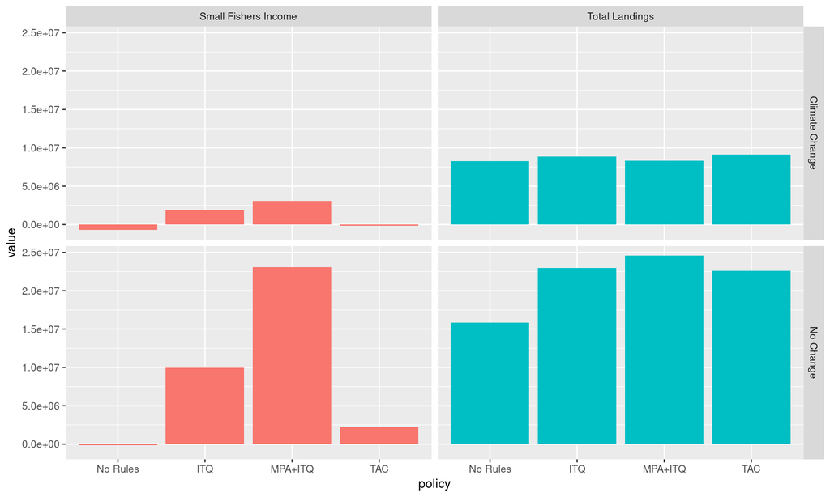

What happens is that both landings and small fishermen income drop. However while landings drop by about half, small fishermen income drop to about 10% non-climate change levels. This is because fish moving off-shore is always bad news for small boats that depend on that particular biomass (either by fishing directly or by selling quotas).

If we can predict the climate change ahead of time and add it to the model, we can do the same optimization process as before to find the new optimal quotas. The posterior shifts left and low, which means that we ought to use smaller quotas but even this will only achieve about half the originally predicted profits.

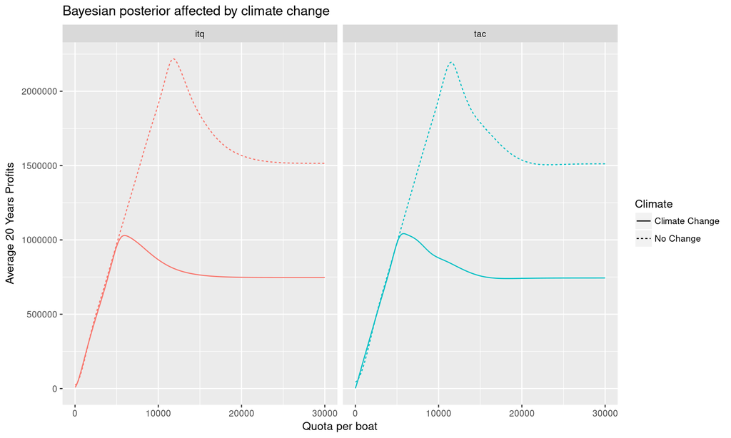

We can do the same by building an MPA+ITQ Pareto front predicting climate change and compare it; as you can see there is no escape the drop in both landings and income. The **X** represents the outcome when we use the non-climate change best policy in a scenario where climate-change actually happens.  
This shows how important it is to either get the model right the first time, or to switch to closed loop policies that hopefully adapt to changes in the environment.

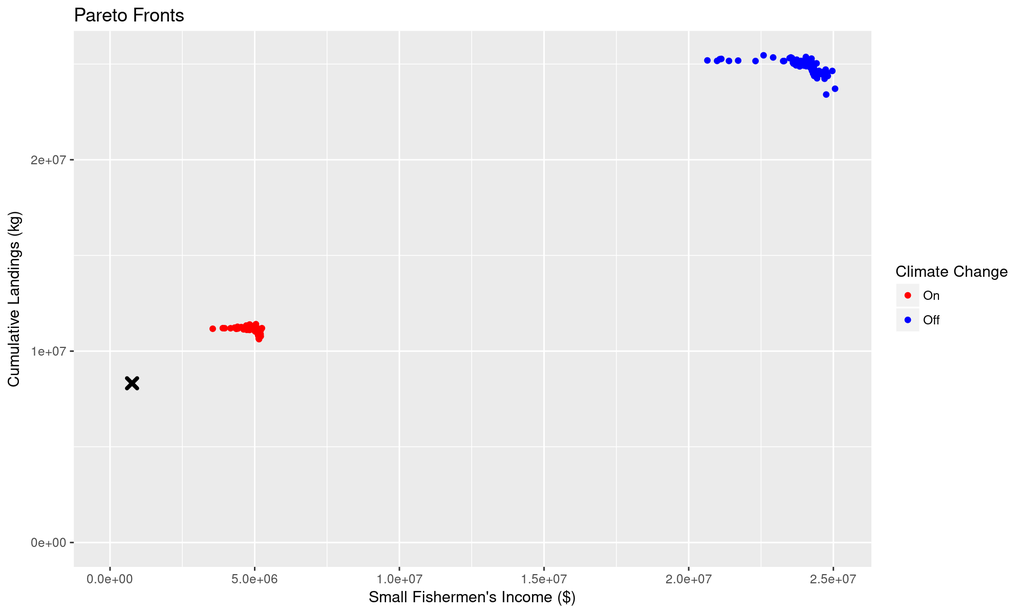